# Reproducible Research: Peer Assessment 1

Aurimas R.

11/15/2014

This is my version of the peer assessment 1 for the (Reproducible Research course on Coursera)[https://class.coursera.org/repdata-008]. We’re working on activity data from a personal activity monitoring device (ala Fitbit). Very awesome!

## Loading and preprocessing data

First, let’s get the data in order. We will also need to do some calculations and by interval, so why not to prepare the datasets accordingly.

```r
unzip('activity.zip')
data <- read.csv('activity.csv')
date_data <- aggregate(list(total_steps=data$steps), by=list(date=data$date), FUN=sum)
interval_data <- aggregate(list(total_steps=data$steps), by=list(interval=data$interval), FUN=function(a) {mean(a, na.rm=TRUE)})
```

## What is mean total number of steps taken per day?

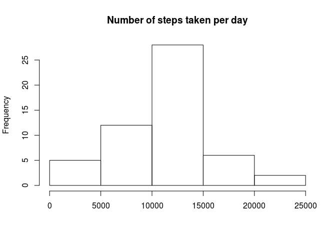

```r
hist(date_data$total_steps, main="Number of steps taken per day", xlab="")
```

```r
mean <- sprintf("%.0f", mean(date_data$total_steps, na.rm=TRUE))
median <- sprintf("%.0f", median(date_data$total_steps, na.rm=TRUE))
```

The average number of steps taken per day is 10766 and the median is 10765.

## What is the average daily activity pattern?

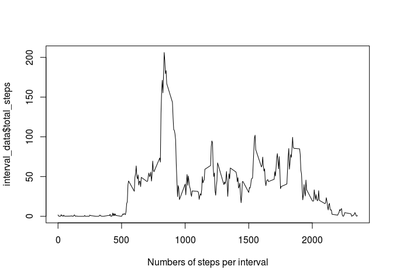

```r
plot(interval_data$interval, interval_data$total_steps, type='l', xlab="Numbers of steps per interval")
```

```r
max <- interval_data$interval[interval_data$total_steps == max(interval_data$total_steps)]
start_time <- format(strptime(x=0, format='%s') + max * 60, "%H:%M", tz='UTC')
end_time <- format(strptime(x=0, format='%s') + (max + 5) * 60, "%H:%M", tz='UTC')
```

## Imputing missing values

```r
missing_values = length(is.na(data$steps))
```

```r
new_data <- data
new_data$steps <- apply(new_data, MARGIN=1, FUN = function(row) {
  if (is.na(row[[1]])) {
    row[[1]] = interval_data$total_steps[interval_data$interval == as.numeric(row[[3]])]
  }
  as.numeric(row[[1]])
})
```

Now, let’s try to recalculate the means/medians on the new dataset.

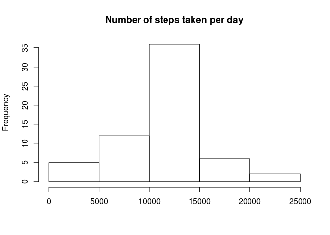

```r
date_data <- aggregate(list(total_steps=new_data$steps), by=list(date=new_data$date), FUN=sum)
hist(date_data$total_steps, main="Number of steps taken per day", xlab="")
```

```r
mean <- sprintf("%.0f", mean(date_data$total_steps, na.rm=TRUE))
median <- sprintf("%.0f", median(date_data$total_steps, na.rm=TRUE))
```

The average number of steps taken per day is 10766 and the median is 10766. Unsurprisingly, there is no change in the mean (as I used the averages to impute the values), but the median went up a bit (as missing values were replaced with values above 0).

## Are there differences in activity patterns between weekdays and weekends?

Alright. First, let’s create a new factor variable.

```r
new_data$day_of_week <- apply(new_data, MARGIN=1, FUN = function(row) {
  day = weekdays(as.Date(row[[2]]), abbreviate = TRUE)
  if (is.element(day, c('Sun', 'Sat'))) {
    factor = 'weekend'
  } else {
    factor = 'weekday'
  }
  factor
})
```

Now, let’s make the plots. I’ll do it with the base plot system.

```r
nd_wd <- new_data[new_data$day_of_week == 'weekday', ]
nd_wk <- new_data[new_data$day_of_week == 'weekend', ]

interval_data_wd <- aggregate(list(total_steps=nd_wd$steps), by=list(interval=nd_wd$interval), FUN=function(a) {mean(a, na.rm=TRUE)})
interval_data_wk <- aggregate(list(total_steps=nd_wk$steps), by=list(interval=nd_wk$interval), FUN=function(a) {mean(a, na.rm=TRUE)})

par(mfcol=c(2,1), mar=c(4,2,4,2), out.extra='style="width=100%"')
```

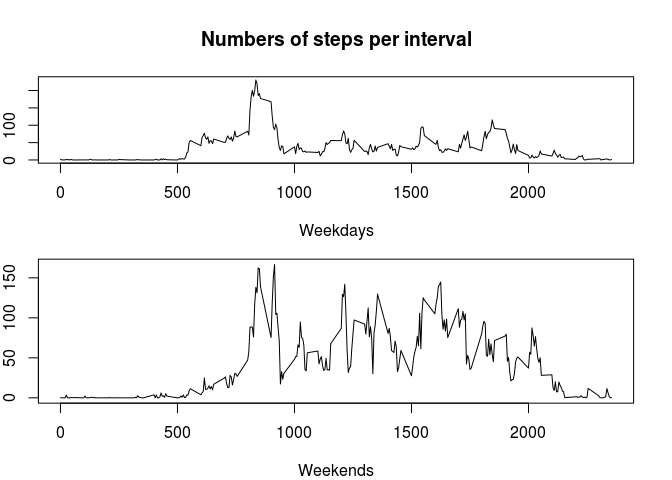

```r
plot(
  interval_data_wd$interval,
  interval_data_wd$total_steps,
  type='l',
  main="Numbers of steps per interval",
  xlab="Weekdays",
  ylab=""
)
par(mar=c(4,2,1,2))
plot(
  interval_data_wk$interval,
  interval_data_wk$total_steps,
  type='l',
  xlab="Weekends",
  ylab=""
)
```